# cox_ph

Yunshen Bai

2023-12-17

```r
library(tidyverse)
library(survival)
library(survminer)
library(MASS)
library(ggplot2)
```

The Cox proportional hazards model is a regression model commonly used in medical research to investigate the association between the survival time of patients and one or more predictor variables. The Cox proportional hazards regression analysis works for both quantitative and categorical predictor variables. The Cox regression model is an extension of survival analysis methods that allows for the simultaneous assessment of the effects of multiple risk factors on survival time.

The purpose of the model is to evaluate how specified factors influence the rate of a particular event occurring at a specific point in time, commonly referred to as the hazard rate. Predictor variables are typically referred to as covariates in the survival analysis literature.

The Cox model was chosen because it is widely used when working with clinical data due to its applicability to a wide variety of studies. The basic formula for the Cox Proportional Hazard model can be written as
$$h(t)=h_{0}(t)exp(\beta_1x_1+\beta_2x_2+...+\beta_px_p)$$
where

- t represents the survival time
- h(t) is the hazard function determined by a set of p covariates ($x_1,x_2,x_p$)
- the coefficients ($\beta_1,\beta_2,...,\beta_p$) measure the impact (i.e., the effect size) of covariates.
- the term $h_0$ is called the baseline hazard. It corresponds to the value of the hazard if all the $x_i$ are equal to zero

The quantities $exp(\beta_i)$ are called hazard ratios (HR). In summary,

- HR = 1: No effect
- HR < 1: Reduction in the hazard
- HR > 1: Increase in Hazard

In this report, we fit our data in Cox PH model to investigate the association between the survival time of patients and one or more predictor variables.

First, we need to clean this dataset. We set several variables as factor, drop the NA value in this dataset.

```r
cancer_df=read_csv("Project_2_data.csv")|>
  janitor::clean_names() |>
  drop_na()

col_names =
  cancer_df |> select_if(is.character) |> colnames() |> as.vector()

cancer_df[,col_names] =
  lapply(cancer_df[,col_names], factor)

cancer_df =
  cancer_df |>
  mutate(
    status =
      case_match(
        status,
        "Alive" ~ 0,
        "Dead" ~ 1)
  )
```

In this report, we will use `coxph` function to fit our Cox proportional hazards model.

```r
model=coxph(Surv(survival_months,status)~.,data=cancer_df)
summary(model)
```

```
## Call:
## coxph(formula = Surv(survival_months, status) ~ ., data = cancer_df)
##
##   n= 4024, number of events= 616
##
##                                         coef exp(coef)  se(coef)      z
## age                                 0.020463  1.020673  0.004873  4.200
## raceOther                          -0.736866  0.478612  0.214042 -3.443
## raceWhite                          -0.370655  0.690282  0.129776 -2.856
## marital_statusMarried              -0.203376  0.815971  0.119228 -1.706
## marital_statusSeparated             0.391784  1.479619  0.290182  1.350
## marital_statusSingle               -0.030024  0.970422  0.146084 -0.206
## marital_statusWidowed              -0.030182  0.970269  0.181574 -0.166
## t_stageT2                           0.201182  1.222847  0.160641  1.252
## t_stageT3                           0.354265  1.425133  0.253364  1.398
## t_stageT4                           0.637921  1.892542  0.313356  2.036
## n_stageN2                           0.568511  1.765636  0.203140  2.799
## n_stageN3                           0.756433  2.130663  0.240152  3.150
## x6th_stageIIB                       0.269771  1.309664  0.201799  1.337
## x6th_stageIIIA                      0.027973  1.028368  0.254824  0.110
## x6th_stageIIIB                      0.202537  1.224505  0.395992  0.511
## x6th_stageIIIC                            NA        NA  0.000000     NA
## differentiatePoorly differentiated  0.351803  1.421629  0.089308  3.939
## differentiateUndifferentiated       1.104912  3.018960  0.349828  3.158
## differentiateWell differentiated   -0.449352  0.638042  0.171180 -2.625
## grade2                                    NA        NA  0.000000     NA
## grade3                                    NA        NA  0.000000     NA
## gradeanaplastic; Grade IV                 NA        NA  0.000000     NA
## a_stageRegional                    -0.150448  0.860322  0.194018 -0.775
## tumor_size                          0.001680  1.001681  0.003161  0.531
## estrogen_statusPositive            -0.648532  0.522813  0.135622 -4.782
## progesterone_statusPositive        -0.486487  0.614782  0.106949 -4.549
## regional_node_examined             -0.033013  0.967526  0.006492 -5.085
## reginol_node_positive               0.058490  1.060234  0.011353  5.152
##                                    Pr(>|z|)
## age                                2.67e-05 ***
## raceOther                          0.000576 ***
## raceWhite                          0.004289 **
## marital_statusMarried              0.088051 .
## marital_statusSeparated            0.176973
```

[output cut: 45 more lines]

```
## differentiateWell differentiated      0.6380     1.5673    0.4562    0.8924
## grade2                                    NA         NA        NA        NA
## grade3                                    NA         NA        NA        NA
## gradeanaplastic; Grade IV                 NA         NA        NA        NA
## a_stageRegional                       0.8603     1.1624    0.5882    1.2584
## tumor_size                            1.0017     0.9983    0.9955    1.0079
## estrogen_statusPositive               0.5228     1.9127    0.4008    0.6820
## progesterone_statusPositive           0.6148     1.6266    0.4985    0.7582
## regional_node_examined                0.9675     1.0336    0.9553    0.9799
## reginol_node_positive                 1.0602     0.9432    1.0369    1.0841
##
## Concordance= 0.744  (se = 0.011 )
## Likelihood ratio test= 501.6  on 24 df,   p=<2e-16
## Wald test            = 570.2  on 24 df,   p=<2e-16
## Score (logrank) test = 665  on 24 df,   p=<2e-16
```

From the above result, we can know that there are a lot of insignificant variables in this model. Therefore, we will perform stepwise model selection to select the best model.

```r
model2=stepAIC(model)
```

```
## Start:  AIC=9384.39
## Surv(survival_months, status) ~ age + race + marital_status +
##     t_stage + n_stage + x6th_stage + differentiate + grade +
##     a_stage + tumor_size + estrogen_status + progesterone_status +
##     regional_node_examined + reginol_node_positive
##
##
## Step:  AIC=9384.39
## Surv(survival_months, status) ~ age + race + marital_status +
##     t_stage + n_stage + x6th_stage + differentiate + a_stage +
##     tumor_size + estrogen_status + progesterone_status + regional_node_examined +
##     reginol_node_positive
##
##                          Df    AIC
## - x6th_stage              3 9380.8
## - t_stage                 3 9382.5
## - tumor_size              1 9382.7
## - a_stage                 1 9383.0
## - marital_status          4 9384.2
## <none>                      9384.4
## - n_stage                 1 9390.6
## - race                    2 9393.5
## - age                     1 9400.3
## - progesterone_status     1 9401.6
## - estrogen_status         1 9404.4
## - reginol_node_positive   1 9407.2
## - regional_node_examined  1 9410.4
## - differentiate           3 9412.9
##
## Step:  AIC=9380.82
## Surv(survival_months, status) ~ age + race + marital_status +
##     t_stage + n_stage + differentiate + a_stage + tumor_size +
##     estrogen_status + progesterone_status + regional_node_examined +
##     reginol_node_positive
##
##                          Df    AIC
## - tumor_size              1 9379.1
## - a_stage                 1 9379.4
## - marital_status          4 9380.5
## <none>                      9380.8
```

[output cut: 48 more lines]

```
## Surv(survival_months, status) ~ age + race + t_stage + n_stage +
##     differentiate + estrogen_status + progesterone_status + regional_node_examined +
##     reginol_node_positive
##
##                          Df    AIC
## <none>                      9377.4
## - race                    2 9390.7
## - n_stage                 2 9391.0
## - age                     1 9395.0
## - progesterone_status     1 9395.2
## - estrogen_status         1 9397.8
## - t_stage                 3 9404.3
## - regional_node_examined  1 9404.4
## - reginol_node_positive   1 9404.5
## - differentiate           3 9406.0
```

```r
summary(model2)
```

```
## Call:
## coxph(formula = Surv(survival_months, status) ~ age + race +
##     t_stage + n_stage + differentiate + estrogen_status + progesterone_status +
##     regional_node_examined + reginol_node_positive, data = cancer_df)
##
##   n= 4024, number of events= 616
##
##                                         coef exp(coef)  se(coef)      z
## age                                 0.020681  1.020896  0.004709  4.392
## raceOther                          -0.824963  0.438251  0.210798 -3.914
## raceWhite                          -0.434022  0.647898  0.126380 -3.434
## t_stageT2                           0.390385  1.477549  0.100597  3.881
## t_stageT3                           0.515086  1.673783  0.127445  4.042
## t_stageT4                           0.942870  2.567340  0.182979  5.153
## n_stageN2                           0.437104  1.548217  0.109006  4.010
## n_stageN3                           0.566361  1.761844  0.178638  3.170
## differentiatePoorly differentiated  0.351012  1.420505  0.089041  3.942
## differentiateUndifferentiated       1.073612  2.925928  0.343971  3.121
## differentiateWell differentiated   -0.451588  0.636616  0.170927 -2.642
## estrogen_statusPositive            -0.649768  0.522167  0.134691 -4.824
## progesterone_statusPositive        -0.492671  0.610992  0.106551 -4.624
## regional_node_examined             -0.033584  0.966974  0.006484 -5.180
## reginol_node_positive               0.063401  1.065454  0.011260  5.631
##                                    Pr(>|z|)
## age                                1.12e-05 ***
## raceOther                          9.10e-05 ***
## raceWhite                          0.000594 ***
## t_stageT2                          0.000104 ***
## t_stageT3                          5.31e-05 ***
## t_stageT4                          2.57e-07 ***
## n_stageN2                          6.07e-05 ***
## n_stageN3                          0.001522 **
## differentiatePoorly differentiated 8.08e-05 ***
## differentiateUndifferentiated      0.001801 **
## differentiateWell differentiated   0.008242 **
## estrogen_statusPositive            1.41e-06 ***
## progesterone_statusPositive        3.77e-06 ***
## regional_node_examined             2.22e-07 ***
## reginol_node_positive              1.80e-08 ***
## ---
```

[output cut: 8 more lines]

```
## t_stageT4                             2.5673     0.3895    1.7936    3.6748
## n_stageN2                             1.5482     0.6459    1.2504    1.9170
## n_stageN3                             1.7618     0.5676    1.2414    2.5005
## differentiatePoorly differentiated    1.4205     0.7040    1.1930    1.6914
## differentiateUndifferentiated         2.9259     0.3418    1.4910    5.7419
## differentiateWell differentiated      0.6366     1.5708    0.4554    0.8900
## estrogen_statusPositive               0.5222     1.9151    0.4010    0.6799
## progesterone_statusPositive           0.6110     1.6367    0.4958    0.7529
## regional_node_examined                0.9670     1.0342    0.9548    0.9793
## reginol_node_positive                 1.0655     0.9386    1.0422    1.0892
##
## Concordance= 0.741  (se = 0.011 )
## Likelihood ratio test= 490.6  on 15 df,   p=<2e-16
## Wald test            = 554.9  on 15 df,   p=<2e-16
## Score (logrank) test = 640.7  on 15 df,   p=<2e-16
```

From the result, there is no insignificant variables in this model. Also, this model passed the Likelihood ratio test, Wald test and Score test. Therefore, we consider this model as our final Cox proportional hazards model.

Hazard function for the patient k is:
$$h_k(t)=h_0(t)exp(0.020681*age-0.824963*I(race=Other)-0.434022*I(race=White)+0.390385*I(t\underline{\text{}}stage=T2)+0.515086*I(t\underline{\text{}}stage=T3)+
0.942870*I(t_stage=T4)+0.437104*I(n\underline{\text{}}stage=N2)+0.566361*I(n\underline{\text{}}stage=N3)+0.351012*I(differentiate=Poorly\;differentiated)+1.073612*I(differentiate=Undifferentiated)-0.451588*I(differentiate=Well\;differentiated)-0.649768*I(estrogen\underline{\text{}}status=Positive)-0.492671*I(progesterone\underline{\text{}}status=Positive)-0.033584*regional\underline{\text{}}node\underline{\text{}}examined+0.063401*reginol\underline{\text{}}node\underline{\text{}}positive)$$

In this report, we are interested in interacting effects of the cox PH model. Therefore, we use exhaustive method to find every possible interaction variable and see whether the model will have a better performance.

```r
model3=coxph(formula = Surv(survival_months, status) ~ (age + race + t_stage + n_stage + differentiate + estrogen_status + progesterone_status + regional_node_examined + reginol_node_positive)^2, data = cancer_df)
```

Also, we will use stepwise to select variables.

```r
model3=stepAIC(model3)
```

```
## Start:  AIC=9442.07
## Surv(survival_months, status) ~ (age + race + t_stage + n_stage +
##     differentiate + estrogen_status + progesterone_status + regional_node_examined +
##     reginol_node_positive)^2
```

[output not shown]

[output cut: 34 more lines]

[output not shown]

```
##                                                Df    AIC
## - race:t_stage                                  6 9431.8
## - t_stage:n_stage                               6 9434.3
## - age:differentiate                             3 9438.1
## - n_stage:reginol_node_positive                 2 9438.1
## - differentiate:estrogen_status                 3 9438.2
## - race:regional_node_examined                   2 9438.4
## - race:n_stage                                  4 9439.0
## - n_stage:regional_node_examined                2 9439.6
## - age:race                                      2 9439.8
## - age:progesterone_status                       1 9440.1
## - progesterone_status:regional_node_examined    1 9440.1
## - n_stage:progesterone_status                   2 9440.1
## - age:t_stage                                   3 9440.2
## - estrogen_status:regional_node_examined        1 9440.3
## - n_stage:estrogen_status                       2 9440.3
## - regional_node_examined:reginol_node_positive  1 9440.3
## - estrogen_status:reginol_node_positive         1 9440.4
## - differentiate:progesterone_status             4 9440.7
## - t_stage:progesterone_status                   3 9440.9
## - race:reginol_node_positive                    2 9441.0
## - t_stage:reginol_node_positive                 3 9441.1
## - progesterone_status:reginol_node_positive     1 9441.2
## - age:n_stage                                   2 9441.5
## - estrogen_status:progesterone_status           1 9441.8
## - age:estrogen_status                           1 9441.9
## - race:estrogen_status                          2 9442.0
## <none>                                            9442.1
## - age:regional_node_examined                    1 9442.1
## - age:reginol_node_positive                     1 9443.8
## - n_stage:differentiate                         7 9443.9
## - t_stage:differentiate                        10 9444.2
## - differentiate:regional_node_examined          4 9446.5
## - race:progesterone_status                      2 9447.5
## - t_stage:regional_node_examined                3 9448.6
## - differentiate:reginol_node_positive           4 9449.9
## - race:differentiate                            6 9450.4
## - t_stage:estrogen_status                       3 9452.5
```

```
##
## Step:  AIC=9431.78
## Surv(survival_months, status) ~ age + race + t_stage + n_stage +
##     differentiate + estrogen_status + progesterone_status + regional_node_examined +
##     reginol_node_positive + age:race + age:t_stage + age:n_stage +
##     age:differentiate + age:estrogen_status + age:progesterone_status +
##     age:regional_node_examined + age:reginol_node_positive +
##     race:n_stage + race:differentiate + race:estrogen_status +
##     race:progesterone_status + race:regional_node_examined +
##     race:reginol_node_positive + t_stage:n_stage + t_stage:differentiate +
##     t_stage:estrogen_status + t_stage:progesterone_status + t_stage:regional_node_examined +
##     t_stage:reginol_node_positive + n_stage:differentiate + n_stage:estrogen_status +
##     n_stage:progesterone_status + n_stage:regional_node_examined +
##     n_stage:reginol_node_positive + differentiate:estrogen_status +
##     differentiate:progesterone_status + differentiate:regional_node_examined +
##     differentiate:reginol_node_positive + estrogen_status:progesterone_status +
##     estrogen_status:regional_node_examined + estrogen_status:reginol_node_positive +
##     progesterone_status:regional_node_examined + progesterone_status:reginol_node_positive +
##     regional_node_examined:reginol_node_positive
```

[output not shown]

[output cut: 31 more lines]

[output not shown]

```
##                                                Df    AIC
## - t_stage:n_stage                               6 9424.7
## - n_stage:reginol_node_positive                 2 9427.8
## - age:differentiate                             3 9427.9
## - differentiate:estrogen_status                 3 9427.9
## - race:regional_node_examined                   2 9428.2
## - race:n_stage                                  4 9428.6
## - n_stage:regional_node_examined                2 9429.3
## - age:race                                      2 9429.5
## - age:t_stage                                   3 9429.7
## - n_stage:progesterone_status                   2 9429.8
## - age:progesterone_status                       1 9429.8
## - progesterone_status:regional_node_examined    1 9429.8
## - estrogen_status:regional_node_examined        1 9430.0
## - n_stage:estrogen_status                       2 9430.0
## - regional_node_examined:reginol_node_positive  1 9430.1
## - estrogen_status:reginol_node_positive         1 9430.2
## - race:reginol_node_positive                    2 9430.3
## - differentiate:progesterone_status             4 9430.4
## - t_stage:progesterone_status                   3 9430.7
## - progesterone_status:reginol_node_positive     1 9431.0
## - age:n_stage                                   2 9431.4
## - t_stage:reginol_node_positive                 3 9431.5
## - estrogen_status:progesterone_status           1 9431.5
## - age:estrogen_status                           1 9431.7
## - race:estrogen_status                          2 9431.8
## <none>                                            9431.8
## - age:regional_node_examined                    1 9431.9
## - n_stage:differentiate                         7 9433.5
## - age:reginol_node_positive                     1 9433.6
## - t_stage:differentiate                        10 9434.0
## - differentiate:regional_node_examined          4 9436.2
## - race:progesterone_status                      2 9437.5
## - t_stage:regional_node_examined                3 9438.3
## - differentiate:reginol_node_positive           4 9439.5
## - race:differentiate                            6 9440.2
## - t_stage:estrogen_status                       3 9442.0
```

```
##
## Step:  AIC=9424.74
## Surv(survival_months, status) ~ age + race + t_stage + n_stage +
##     differentiate + estrogen_status + progesterone_status + regional_node_examined +
##     reginol_node_positive + age:race + age:t_stage + age:n_stage +
##     age:differentiate + age:estrogen_status + age:progesterone_status +
##     age:regional_node_examined + age:reginol_node_positive +
##     race:n_stage + race:differentiate + race:estrogen_status +
##     race:progesterone_status + race:regional_node_examined +
##     race:reginol_node_positive + t_stage:differentiate + t_stage:estrogen_status +
##     t_stage:progesterone_status + t_stage:regional_node_examined +
##     t_stage:reginol_node_positive + n_stage:differentiate + n_stage:estrogen_status +
##     n_stage:progesterone_status + n_stage:regional_node_examined +
##     n_stage:reginol_node_positive + differentiate:estrogen_status +
##     differentiate:progesterone_status + differentiate:regional_node_examined +
##     differentiate:reginol_node_positive + estrogen_status:progesterone_status +
##     estrogen_status:regional_node_examined + estrogen_status:reginol_node_positive +
##     progesterone_status:regional_node_examined + progesterone_status:reginol_node_positive +
##     regional_node_examined:reginol_node_positive
```

[output not shown]

[output cut: 28 more lines]

[output not shown]

```
##                                                Df    AIC
## - n_stage:reginol_node_positive                 2 9420.7
## - differentiate:estrogen_status                 3 9420.8
## - age:differentiate                             3 9420.9
## - race:regional_node_examined                   2 9421.1
## - race:n_stage                                  4 9421.2
## - n_stage:regional_node_examined                2 9421.6
## - age:t_stage                                   3 9422.1
## - age:race                                      2 9422.5
## - regional_node_examined:reginol_node_positive  1 9422.7
## - progesterone_status:regional_node_examined    1 9422.8
## - age:progesterone_status                       1 9422.8
## - estrogen_status:regional_node_examined        1 9422.9
## - n_stage:progesterone_status                   2 9422.9
## - race:reginol_node_positive                    2 9423.1
## - differentiate:progesterone_status             4 9423.1
## - estrogen_status:reginol_node_positive         1 9423.3
## - n_stage:estrogen_status                       2 9423.5
## - progesterone_status:reginol_node_positive     1 9424.0
## - t_stage:progesterone_status                   3 9424.1
## - age:n_stage                                   2 9424.2
## - estrogen_status:progesterone_status           1 9424.2
## - age:estrogen_status                           1 9424.5
## - race:estrogen_status                          2 9424.6
## - age:regional_node_examined                    1 9424.7
## <none>                                            9424.7
## - t_stage:reginol_node_positive                 3 9425.2
## - n_stage:differentiate                         7 9426.3
## - age:reginol_node_positive                     1 9426.5
## - t_stage:differentiate                        10 9426.8
## - differentiate:regional_node_examined          4 9429.1
## - race:progesterone_status                      2 9430.0
## - t_stage:regional_node_examined                3 9430.3
## - differentiate:reginol_node_positive           4 9432.1
## - race:differentiate                            6 9432.6
## - t_stage:estrogen_status                       3 9435.0
```

```
##
## Step:  AIC=9420.74
## Surv(survival_months, status) ~ age + race + t_stage + n_stage +
##     differentiate + estrogen_status + progesterone_status + regional_node_examined +
##     reginol_node_positive + age:race + age:t_stage + age:n_stage +
##     age:differentiate + age:estrogen_status + age:progesterone_status +
##     age:regional_node_examined + age:reginol_node_positive +
##     race:n_stage + race:differentiate + race:estrogen_status +
##     race:progesterone_status + race:regional_node_examined +
##     race:reginol_node_positive + t_stage:differentiate + t_stage:estrogen_status +
##     t_stage:progesterone_status + t_stage:regional_node_examined +
##     t_stage:reginol_node_positive + n_stage:differentiate + n_stage:estrogen_status +
##     n_stage:progesterone_status + n_stage:regional_node_examined +
##     differentiate:estrogen_status + differentiate:progesterone_status +
##     differentiate:regional_node_examined + differentiate:reginol_node_positive +
##     estrogen_status:progesterone_status + estrogen_status:regional_node_examined +
##     estrogen_status:reginol_node_positive + progesterone_status:regional_node_examined +
##     progesterone_status:reginol_node_positive + regional_node_examined:reginol_node_positive
```

[output not shown]

[output cut: 25 more lines]

[output not shown]

```
##                                                Df    AIC
## - differentiate:estrogen_status                 3 9416.8
## - age:differentiate                             3 9416.9
## - race:regional_node_examined                   2 9417.1
## - race:n_stage                                  4 9417.2
## - n_stage:regional_node_examined                2 9417.7
## - age:t_stage                                   3 9418.2
## - age:race                                      2 9418.5
## - regional_node_examined:reginol_node_positive  1 9418.7
## - progesterone_status:regional_node_examined    1 9418.8
## - age:progesterone_status                       1 9418.8
## - estrogen_status:regional_node_examined        1 9418.9
## - n_stage:progesterone_status                   2 9418.9
## - race:reginol_node_positive                    2 9419.1
## - differentiate:progesterone_status             4 9419.1
## - estrogen_status:reginol_node_positive         1 9419.3
## - n_stage:estrogen_status                       2 9419.5
## - progesterone_status:reginol_node_positive     1 9420.0
## - t_stage:progesterone_status                   3 9420.1
## - age:n_stage                                   2 9420.2
## - estrogen_status:progesterone_status           1 9420.2
## - age:estrogen_status                           1 9420.5
## - race:estrogen_status                          2 9420.6
## - age:regional_node_examined                    1 9420.7
## <none>                                            9420.7
## - t_stage:reginol_node_positive                 3 9421.3
## - n_stage:differentiate                         7 9422.3
## - age:reginol_node_positive                     1 9422.5
## - t_stage:differentiate                        10 9422.8
## - differentiate:regional_node_examined          4 9425.1
## - race:progesterone_status                      2 9426.0
## - t_stage:regional_node_examined                3 9426.3
## - differentiate:reginol_node_positive           4 9428.2
## - race:differentiate                            6 9428.6
## - t_stage:estrogen_status                       3 9431.1
```

```
##
## Step:  AIC=9416.81
## Surv(survival_months, status) ~ age + race + t_stage + n_stage +
##     differentiate + estrogen_status + progesterone_status + regional_node_examined +
##     reginol_node_positive + age:race + age:t_stage + age:n_stage +
##     age:differentiate + age:estrogen_status + age:progesterone_status +
##     age:regional_node_examined + age:reginol_node_positive +
##     race:n_stage + race:differentiate + race:estrogen_status +
##     race:progesterone_status + race:regional_node_examined +
##     race:reginol_node_positive + t_stage:differentiate + t_stage:estrogen_status +
##     t_stage:progesterone_status + t_stage:regional_node_examined +
##     t_stage:reginol_node_positive + n_stage:differentiate + n_stage:estrogen_status +
##     n_stage:progesterone_status + n_stage:regional_node_examined +
##     differentiate:progesterone_status + differentiate:regional_node_examined +
##     differentiate:reginol_node_positive + estrogen_status:progesterone_status +
##     estrogen_status:regional_node_examined + estrogen_status:reginol_node_positive +
##     progesterone_status:regional_node_examined + progesterone_status:reginol_node_positive +
##     regional_node_examined:reginol_node_positive
```

[output not shown]

[output cut: 19 more lines]

[output not shown]

```
##                                                Df    AIC
## - race:regional_node_examined                   2 9413.2
## - race:n_stage                                  4 9413.4
## - age:differentiate                             4 9413.5
## - n_stage:regional_node_examined                2 9413.8
## - age:t_stage                                   3 9414.2
## - age:race                                      2 9414.6
## - regional_node_examined:reginol_node_positive  1 9414.8
## - age:progesterone_status                       1 9414.8
## - progesterone_status:regional_node_examined    1 9414.9
## - estrogen_status:regional_node_examined        1 9415.0
## - n_stage:progesterone_status                   2 9415.1
## - race:reginol_node_positive                    2 9415.2
## - n_stage:estrogen_status                       2 9415.2
## - estrogen_status:reginol_node_positive         1 9415.3
## - progesterone_status:reginol_node_positive     1 9416.1
## - t_stage:progesterone_status                   3 9416.1
## - estrogen_status:progesterone_status           1 9416.2
## - age:n_stage                                   2 9416.4
## - race:estrogen_status                          2 9416.5
## - age:regional_node_examined                    1 9416.6
## - age:estrogen_status                           1 9416.7
## - differentiate:progesterone_status             4 9416.7
## <none>                                            9416.8
## - t_stage:reginol_node_positive                 3 9417.5
## - n_stage:differentiate                         7 9418.5
## - age:reginol_node_positive                     1 9418.5
## - t_stage:differentiate                        10 9420.7
## - race:progesterone_status                      2 9421.7
## - t_stage:regional_node_examined                3 9422.5
## - race:differentiate                            6 9424.4
## - differentiate:reginol_node_positive           4 9425.3
## - differentiate:regional_node_examined          4 9425.7
## - t_stage:estrogen_status                       3 9426.6
```

```
##
## Step:  AIC=9413.17
## Surv(survival_months, status) ~ age + race + t_stage + n_stage +
##     differentiate + estrogen_status + progesterone_status + regional_node_examined +
##     reginol_node_positive + age:race + age:t_stage + age:n_stage +
##     age:differentiate + age:estrogen_status + age:progesterone_status +
##     age:regional_node_examined + age:reginol_node_positive +
##     race:n_stage + race:differentiate + race:estrogen_status +
##     race:progesterone_status + race:reginol_node_positive + t_stage:differentiate +
##     t_stage:estrogen_status + t_stage:progesterone_status + t_stage:regional_node_examined +
##     t_stage:reginol_node_positive + n_stage:differentiate + n_stage:estrogen_status +
##     n_stage:progesterone_status + n_stage:regional_node_examined +
##     differentiate:progesterone_status + differentiate:regional_node_examined +
##     differentiate:reginol_node_positive + estrogen_status:progesterone_status +
##     estrogen_status:regional_node_examined + estrogen_status:reginol_node_positive +
##     progesterone_status:regional_node_examined + progesterone_status:reginol_node_positive +
##     regional_node_examined:reginol_node_positive
```

[output not shown]

[output cut: 16 more lines]

[output not shown]

```
##                                                Df    AIC
## - age:differentiate                             4 9409.9
## - race:n_stage                                  4 9409.9
## - n_stage:regional_node_examined                2 9410.2
## - age:t_stage                                   3 9410.6
## - age:race                                      2 9411.0
## - regional_node_examined:reginol_node_positive  1 9411.2
## - age:progesterone_status                       1 9411.2
## - progesterone_status:regional_node_examined    1 9411.2
## - estrogen_status:regional_node_examined        1 9411.3
## - n_stage:progesterone_status                   2 9411.5
## - n_stage:estrogen_status                       2 9411.5
## - estrogen_status:reginol_node_positive         1 9411.6
## - progesterone_status:reginol_node_positive     1 9412.4
## - race:reginol_node_positive                    2 9412.4
## - estrogen_status:progesterone_status           1 9412.5
## - t_stage:progesterone_status                   3 9412.7
## - age:n_stage                                   2 9412.8
## - age:estrogen_status                           1 9413.0
## - differentiate:progesterone_status             4 9413.0
## - age:regional_node_examined                    1 9413.0
## - race:estrogen_status                          2 9413.1
## <none>                                            9413.2
## - t_stage:reginol_node_positive                 3 9413.9
## - n_stage:differentiate                         7 9414.8
## - age:reginol_node_positive                     1 9414.9
## - t_stage:differentiate                        10 9417.0
## - race:progesterone_status                      2 9418.3
## - t_stage:regional_node_examined                3 9418.9
## - race:differentiate                            6 9420.7
## - differentiate:reginol_node_positive           4 9421.6
## - differentiate:regional_node_examined          4 9422.0
## - t_stage:estrogen_status                       3 9423.2
##
## Step:  AIC=9409.89
## Surv(survival_months, status) ~ age + race + t_stage + n_stage +
##     differentiate + estrogen_status + progesterone_status + regional_node_examined +
##     reginol_node_positive + age:race + age:t_stage + age:n_stage +
##     age:estrogen_status + age:progesterone_status + age:regional_node_examined +
##     age:reginol_node_positive + race:n_stage + race:differentiate +
```

[output cut: 43 more lines]

```
## Step:  AIC=9406.6
## Surv(survival_months, status) ~ age + race + t_stage + n_stage +
##     differentiate + estrogen_status + progesterone_status + regional_node_examined +
##     reginol_node_positive + age:race + age:t_stage + age:n_stage +
##     age:estrogen_status + age:progesterone_status + age:regional_node_examined +
##     age:reginol_node_positive + race:differentiate + race:estrogen_status +
##     race:progesterone_status + race:reginol_node_positive + t_stage:differentiate +
##     t_stage:estrogen_status + t_stage:progesterone_status + t_stage:regional_node_examined +
##     t_stage:reginol_node_positive + n_stage:differentiate + n_stage:estrogen_status +
##     n_stage:progesterone_status + n_stage:regional_node_examined +
##     differentiate:progesterone_status + differentiate:regional_node_examined +
##     differentiate:reginol_node_positive + estrogen_status:progesterone_status +
##     estrogen_status:regional_node_examined + estrogen_status:reginol_node_positive +
##     progesterone_status:regional_node_examined + progesterone_status:reginol_node_positive +
##     regional_node_examined:reginol_node_positive
```

```
##                                                Df    AIC
## - race:reginol_node_positive                    2 9402.6
## - n_stage:regional_node_examined                2 9403.5
## - age:race                                      2 9404.1
## - age:t_stage                                   3 9404.4
## - age:progesterone_status                       1 9404.6
## - regional_node_examined:reginol_node_positive  1 9404.6
## - progesterone_status:regional_node_examined    1 9404.7
## - estrogen_status:regional_node_examined        1 9404.8
## - n_stage:estrogen_status                       2 9405.1
## - estrogen_status:reginol_node_positive         1 9405.3
## - n_stage:progesterone_status                   2 9405.4
## - age:n_stage                                   2 9406.1
## - progesterone_status:reginol_node_positive     1 9406.1
## - t_stage:progesterone_status                   3 9406.3
## - age:regional_node_examined                    1 9406.4
## - race:estrogen_status                          2 9406.5
## <none>                                            9406.6
## - differentiate:progesterone_status             3 9406.7
## - estrogen_status:progesterone_status           1 9406.9
## - t_stage:reginol_node_positive                 3 9406.9
## - age:estrogen_status                           1 9407.8
## - age:reginol_node_positive                     1 9408.0
## - n_stage:differentiate                         6 9409.6
## - race:progesterone_status                      2 9411.1
## - t_stage:regional_node_examined                3 9412.3
## - t_stage:differentiate                         9 9413.2
## - differentiate:regional_node_examined          3 9415.2
## - race:differentiate                            5 9415.3
## - t_stage:estrogen_status                       3 9416.0
## - differentiate:reginol_node_positive           3 9416.4
##
## Step:  AIC=9402.65
## Surv(survival_months, status) ~ age + race + t_stage + n_stage +
##     differentiate + estrogen_status + progesterone_status + regional_node_examined +
##     reginol_node_positive + age:race + age:t_stage + age:n_stage +
##     age:estrogen_status + age:progesterone_status + age:regional_node_examined +
##     age:reginol_node_positive + race:differentiate + race:estrogen_status +
##     race:progesterone_status + t_stage:differentiate + t_stage:estrogen_status +
##     t_stage:progesterone_status + t_stage:regional_node_examined +
##     t_stage:reginol_node_positive + n_stage:differentiate + n_stage:estrogen_status +
##     n_stage:progesterone_status + n_stage:regional_node_examined +
##     differentiate:progesterone_status + differentiate:regional_node_examined +
##     differentiate:reginol_node_positive + estrogen_status:progesterone_status +
##     estrogen_status:regional_node_examined + estrogen_status:reginol_node_positive +
##     progesterone_status:regional_node_examined + progesterone_status:reginol_node_positive +
##     regional_node_examined:reginol_node_positive
```

```
##                                                Df    AIC
## - n_stage:regional_node_examined                2 9399.6
## - age:race                                      2 9400.2
## - age:t_stage                                   3 9400.4
## - age:progesterone_status                       1 9400.6
## - regional_node_examined:reginol_node_positive  1 9400.7
## - progesterone_status:regional_node_examined    1 9400.7
## - estrogen_status:regional_node_examined        1 9400.8
## - n_stage:estrogen_status                       2 9401.2
## - estrogen_status:reginol_node_positive         1 9401.3
## - n_stage:progesterone_status                   2 9401.5
## - age:n_stage                                   2 9402.1
## - progesterone_status:reginol_node_positive     1 9402.1
## - t_stage:progesterone_status                   3 9402.3
## - age:regional_node_examined                    1 9402.4
## - race:estrogen_status                          2 9402.6
## <none>                                            9402.6
## - differentiate:progesterone_status             3 9402.7
## - t_stage:reginol_node_positive                 3 9402.9
## - estrogen_status:progesterone_status           1 9403.0
## - age:estrogen_status                           1 9403.9
## - age:reginol_node_positive                     1 9404.0
## - n_stage:differentiate                         6 9405.6
## - race:progesterone_status                      2 9407.1
## - t_stage:regional_node_examined                3 9408.4
## - t_stage:differentiate                         9 9409.2
## - differentiate:regional_node_examined          3 9411.3
## - race:differentiate                            5 9411.3
## - t_stage:estrogen_status                       3 9412.1
## - differentiate:reginol_node_positive           3 9412.5
##
## Step:  AIC=9399.57
## Surv(survival_months, status) ~ age + race + t_stage + n_stage +
##     differentiate + estrogen_status + progesterone_status + regional_node_examined +
##     reginol_node_positive + age:race + age:t_stage + age:n_stage +
##     age:estrogen_status + age:progesterone_status + age:regional_node_examined +
##     age:reginol_node_positive + race:differentiate + race:estrogen_status +
##     race:progesterone_status + t_stage:differentiate + t_stage:estrogen_status +
##     t_stage:progesterone_status + t_stage:regional_node_examined +
##     t_stage:reginol_node_positive + n_stage:differentiate + n_stage:estrogen_status +
```

[output cut: 278 more lines]

```
## - differentiate:reginol_node_positive           3 9397.0
## - t_stage:estrogen_status                       3 9399.4
##
## Step:  AIC=9385.72
## Surv(survival_months, status) ~ age + race + t_stage + n_stage +
##     differentiate + estrogen_status + progesterone_status + regional_node_examined +
##     reginol_node_positive + age:n_stage + age:estrogen_status +
##     age:regional_node_examined + age:reginol_node_positive +
##     race:differentiate + race:estrogen_status + race:progesterone_status +
##     t_stage:differentiate + t_stage:estrogen_status + t_stage:progesterone_status +
##     t_stage:regional_node_examined + t_stage:reginol_node_positive +
##     n_stage:differentiate + n_stage:progesterone_status + differentiate:progesterone_status +
##     differentiate:regional_node_examined + differentiate:reginol_node_positive +
##     estrogen_status:progesterone_status + progesterone_status:reginol_node_positive +
##     regional_node_examined:reginol_node_positive
```

```
##                                                Df    AIC
## - n_stage:progesterone_status                   2 9382.6
## - regional_node_examined:reginol_node_positive  1 9384.3
## - progesterone_status:reginol_node_positive     1 9384.9
## - t_stage:progesterone_status                   3 9385.4
## - age:regional_node_examined                    1 9385.6
## - differentiate:progesterone_status             3 9385.7
## <none>                                            9385.7
## - race:estrogen_status                          2 9385.8
## - estrogen_status:progesterone_status           1 9385.9
## - t_stage:reginol_node_positive                 3 9386.0
## - age:n_stage                                   2 9386.6
## - age:reginol_node_positive                     1 9387.8
## - n_stage:differentiate                         6 9388.9
## - race:progesterone_status                      2 9389.8
## - age:estrogen_status                           1 9390.1
## - t_stage:regional_node_examined                3 9391.8
## - t_stage:differentiate                         9 9392.7
## - differentiate:regional_node_examined          3 9393.9
## - race:differentiate                            5 9394.5
## - differentiate:reginol_node_positive           3 9395.7
## - t_stage:estrogen_status                       3 9396.1
##
## Step:  AIC=9382.6
## Surv(survival_months, status) ~ age + race + t_stage + n_stage +
##     differentiate + estrogen_status + progesterone_status + regional_node_examined +
##     reginol_node_positive + age:n_stage + age:estrogen_status +
##     age:regional_node_examined + age:reginol_node_positive +
##     race:differentiate + race:estrogen_status + race:progesterone_status +
##     t_stage:differentiate + t_stage:estrogen_status + t_stage:progesterone_status +
##     t_stage:regional_node_examined + t_stage:reginol_node_positive +
##     n_stage:differentiate + differentiate:progesterone_status +
##     differentiate:regional_node_examined + differentiate:reginol_node_positive +
##     estrogen_status:progesterone_status + progesterone_status:reginol_node_positive +
##     regional_node_examined:reginol_node_positive
##
##                                                Df    AIC
## - regional_node_examined:reginol_node_positive  1 9381.2
## - t_stage:progesterone_status                   3 9381.9
## - progesterone_status:reginol_node_positive     1 9382.3
```

[output cut: 14 more lines]

```
## - race:differentiate                            5 9391.4
## - differentiate:reginol_node_positive           3 9392.6
## - t_stage:estrogen_status                       3 9393.1
##
## Step:  AIC=9381.16
## Surv(survival_months, status) ~ age + race + t_stage + n_stage +
##     differentiate + estrogen_status + progesterone_status + regional_node_examined +
##     reginol_node_positive + age:n_stage + age:estrogen_status +
##     age:regional_node_examined + age:reginol_node_positive +
##     race:differentiate + race:estrogen_status + race:progesterone_status +
##     t_stage:differentiate + t_stage:estrogen_status + t_stage:progesterone_status +
##     t_stage:regional_node_examined + t_stage:reginol_node_positive +
##     n_stage:differentiate + differentiate:progesterone_status +
##     differentiate:regional_node_examined + differentiate:reginol_node_positive +
##     estrogen_status:progesterone_status + progesterone_status:reginol_node_positive
```

```
##                                             Df    AIC
## - t_stage:progesterone_status                3 9380.6
## - progesterone_status:reginol_node_positive  1 9380.8
## - age:regional_node_examined                 1 9381.0
## <none>                                         9381.2
## - race:estrogen_status                       2 9381.2
## - differentiate:progesterone_status          3 9381.3
## - estrogen_status:progesterone_status        1 9381.5
## - t_stage:reginol_node_positive              3 9381.9
## - age:n_stage                                2 9381.9
## - age:reginol_node_positive                  1 9383.1
## - n_stage:differentiate                      6 9384.2
## - race:progesterone_status                   2 9385.2
## - age:estrogen_status                        1 9385.6
## - t_stage:regional_node_examined             3 9387.5
## - t_stage:differentiate                      9 9388.3
## - differentiate:regional_node_examined       3 9389.6
## - race:differentiate                         5 9390.1
## - differentiate:reginol_node_positive        3 9391.2
## - t_stage:estrogen_status                    3 9392.0
##
## Step:  AIC=9380.58
## Surv(survival_months, status) ~ age + race + t_stage + n_stage +
##     differentiate + estrogen_status + progesterone_status + regional_node_examined +
##     reginol_node_positive + age:n_stage + age:estrogen_status +
##     age:regional_node_examined + age:reginol_node_positive +
##     race:differentiate + race:estrogen_status + race:progesterone_status +
##     t_stage:differentiate + t_stage:estrogen_status + t_stage:regional_node_examined +
##     t_stage:reginol_node_positive + n_stage:differentiate + differentiate:progesterone_status +
##     differentiate:regional_node_examined + differentiate:reginol_node_positive +
##     estrogen_status:progesterone_status + progesterone_status:reginol_node_positive
##
##                                             Df    AIC
## - age:regional_node_examined                 1 9380.0
## - differentiate:progesterone_status          3 9380.3
## - estrogen_status:progesterone_status        1 9380.4
## <none>                                         9380.6
## - race:estrogen_status                       2 9380.7
## - progesterone_status:reginol_node_positive  1 9380.8
## - age:n_stage                                2 9381.5
```

[output cut: 218 more lines]

```
##     race:progesterone_status + t_stage:estrogen_status + t_stage:regional_node_examined +
##     t_stage:reginol_node_positive + differentiate:reginol_node_positive +
##     progesterone_status:reginol_node_positive
##
##                                             Df    AIC
## <none>                                         9364.3
## - race:estrogen_status                       2 9364.3
## - t_stage:reginol_node_positive              3 9364.7
## - progesterone_status:reginol_node_positive  1 9364.8
## - differentiate:reginol_node_positive        3 9365.3
## - age:estrogen_status                        1 9366.5
## - race:progesterone_status                   2 9368.2
## - t_stage:estrogen_status                    3 9370.1
## - t_stage:regional_node_examined             3 9371.0
## - n_stage                                    2 9375.1
```

```r
model3=update(model3,.~.-race:estrogen_status-t_stage:regional_node_examined-t_stage:reginol_node_positive -differentiate:reginol_node_positive-progesterone_status:reginol_node_positive)
```

Then, we use AIC to compare the model without interaction variables and model with interaction variables.

```r
AIC(model2,model3)
```

```
##        df      AIC
## model2 15 9377.367
## model3 21 9367.891
```

Since model with interaction variables has smaller AIC, we consider this model as our final model.

After fitting the Cox model to the data, it is possible to visualize the predicted survival for a specific risk group at any given time point. The function `survfit` estimates survival proportions.

Unlike the KM survival curve, the Cox model fit curve outputs the predicted survival after correcting for other variables, rather than the actual observed survival.

[figure not shown]

```r
ggsurvplot(survfit(model3,data=cancer_df), palette= '#2E9FDF',
           ggtheme = theme_minimal())
```

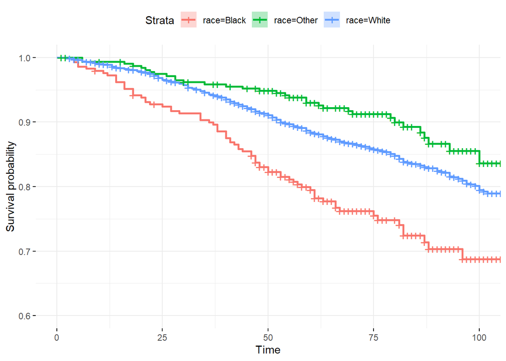

```r
fit <- survfit(Surv(survival_months,status)~race,data=cancer_df)
ggsurvplot(fit, conf.int = TRUE,
           ggtheme = theme_minimal(),ylim=c(0.6,1))
```